# Vignette 2: Build BIO-WELL survey

# Introduction

In this vignette, we will focus on building surveys that include the [BIO-WELL scale](https://doi.org/10.1016/j.jenvp.2022.101921) using the `BIOWELL` package function `build_survey()`.

In Vignette 1, you created a folder for storing your BIO-WELL survey data, including the Dropbox token. In this folder, you will need to save an R script named “app.R” which includes `BIOWELL::build_survey()` with your custom arguments filled inside the function.

It is important that **no other lines of code are included**, and that the function is called using the **double colon operator**, instead of `library(BIOWELL)`.

**Note: Before distributing BIO-WELL surveys, please ensure that you have followed your organisation’s procedures for gaining ethics approval, including participant consent, and data protection and management guidelines.**

## What is the BIO-WELL scale?

To investigate the contribution of biodiversity to human wellbeing, there is a need for a psychometric scale.

The [BIO-WELL scale](https://doi.org/10.1016/j.jenvp.2022.101921) is a reliable and validated, self-reported wellbeing scale with strong psychometric properties.

The scale has been designed to investigate the biodiversity-health/wellbeing relationship by capturing the multi-sensory, holistic experience of biodiversity across five wellbeing domains (Table 1).

**Table 1: The five wellbeing domains included within the BIO-WELL scale**

| Category | Description |
| --- | --- |
| Physical wellbeing | related to the functioning of the physical body and how one feels physically, including recovery from stress. |
| Emotional wellbeing | the experience of positive and negative emotions and mood. |
| Cognitive wellbeing | an individual’s thoughts about their life and cognitive capacity to direct attention. |
| Social wellbeing | how an individual perceives their connections with others. |
| Spiritual wellbeing | concerned with meaning and connection to something greater than oneself. |

These domains are measured using five labelled sliders that survey participants can use to indicate their response to certain biodiversity attributes (Figure 1).

The values for each slider range from 0 to 100. Using the raw slider output, scores can be interpreted as follows: low scores (0–49) indicate a positive wellbeing response, high scores (51–100) a negative response and a score of 50 can be considered neutral.

BIO-WELL scores are calculated by taking the mean value across all wellbeing response items (the five sliders).

**However, to aid interpretability scores can be inverted (0–49 = negative wellbeing; 51–100 = positive wellbeing; 50 = neutral)**

# Survey sections

BIO-WELL surveys are split into six key sections that can be customised using arguments within the `BIOWELL` package function `build_survey()`:

1. Sidebar - These are details that the participants will see throughout the survey.
2. Screening - Here you can add survey questions where certain responses will remove the participant from completing the rest of the survey.
3. Start - An opportunity to add survey questions prior to the BIO-WELL questions.
4. BIO-WELL - For each situation given, a page with questions will be generated. Each question will be accompanied by the five sliders included in the BIO-WELL scale.
5. End - An opportunity to add survey questions following the BIO-WELL questions.
6. Report (optional) - After a participants submits their survey responses, if desired, a page is loaded that summarises their BIO-WELL scores and relates these to that of other survey participants.

Below, we outline and describe the arguments that can be used to customise each section of the survey to your research.

# Section 1: Sidebar

- `survey_title` - Text summarizing the topic of your survey.
- `sidepanel_message`- Text containing general information for survey participants.
- `organisation_website` - Valid URL for organisation running the survey.
- `organisation`- Name of organisation running the survey.

```r
survey_title = "Forest biodiversity and human wellbeing"
sidepanel_message = "The questions in this survey are designed to explore the role forest biodiversity plays in wellbeing."
organisation = "BIOWELL package example"
organisation_website = "https://github.com/r-a-dobson/BIOWELL"
```

# Section 2: Screening

We recommend using this section to gain participant consent to the survey, following your organisation’s procedures and recommendations. This should include a “no” option that will remove participants if they do not consent to taking part in the survey.

- `screen_message` - Text that appears at the top of the page containing the screening questions.
- `screen_questions` - A string (one question) or vector (2+ questions) containing questions that will be accompanied by a select box (drop down list) for responses.
- `screen_questions_ID` - A string or vector (same length as screen_questions) providing a unique ID for the screening question(s). This is used in the resulting data frame of participant responses to avoid lengthy column names which occurs if question text is used.
- `screen_response_options` - A list, where each element contains a vector of response options for the screening questions. In order to set which responses within this list should result in a participants removal from the survey, add “:SCREEN” to the end of the string. See the example below.

Below are examples of how these arguments could be input:

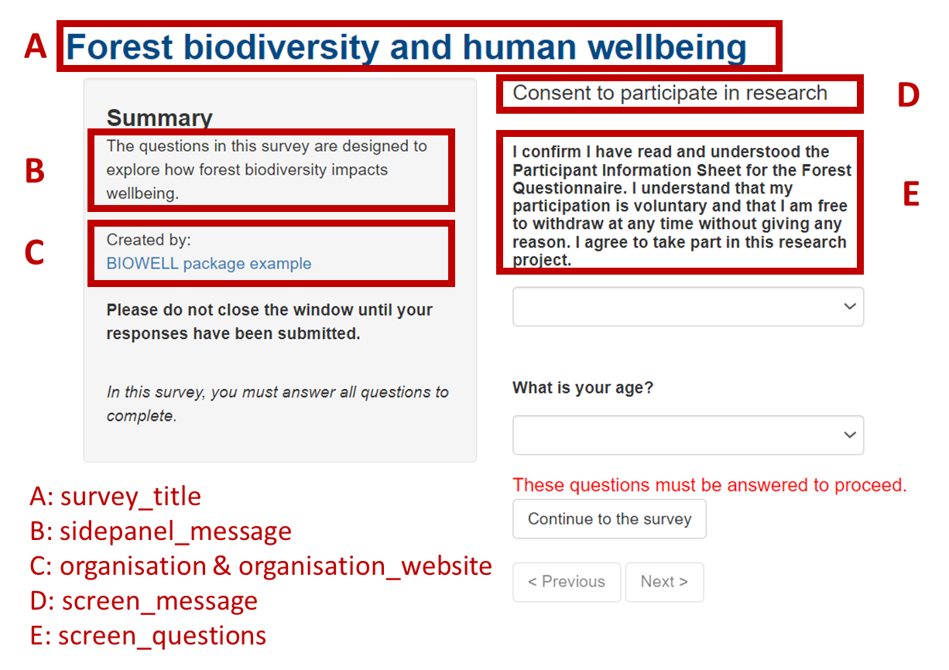

Example of sidepanel and screening section

```r
screen_message = "Consent to participate in research"

screen_questions = c(
  "Participation is voluntary and you can withdraw from the study at any point by exiting
the survey before you submit, without providing any reason for why you no longer want your
responses to be included, and there will be no adverse consequences if you choose to
withdraw. As this survey is anonymised, it will not be possible to withdraw your responses
from the study after you click on 'Submit' at the end of the survey", # Question 1

  "What is your age?") # Question 2

screen_questions_ID = c("Consent", "Age")

screen_response_options = list(c("No:SCREEN", "Yes"), # First element - choices for the first Q
                               c('0-17:SCREEN',  # Second element - choices for the second Q
                                 '18-29',
                                 '30-59',
                                 'Over 60',
                                 'Prefer not to say'))

# Here individuals will be removed if they answer "no" to the consent questions,
# and if they answer "0-17" to the age question.
```

# Section 3: Start

- `start_message` - Text introducing the start questions to participants.
- `start_questions` - a character string (1 question) or vector (2+ questions), the questions to ask participants before the BIO-WELL questions.
- `start_questions_ID` - A character string or vector (equal length to `start_questions`) providing a unique ID for each start question(s). This is used in the resulting data frame of participant responses to avoid lengthy column names which occurs if question text is used.
- `start_questions_type`- A character tring or vector (equal length to `start_questions`) specifying the type of response box to provide for each `start_questions` (provide these in the same order as `start_questions`). We include five options:
  1. `text`: participants can freely type their responses.

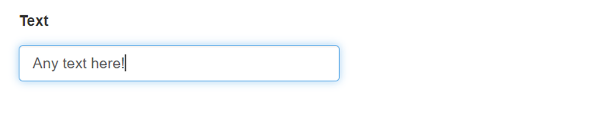

  text

  2. `selectbox`: participants can select one option from a drop down list.

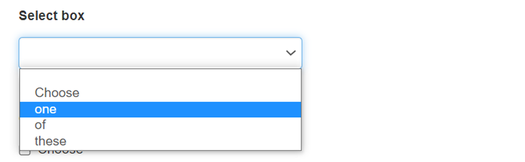

  select box

  3. `checkbox`: participants can select one or more from list using check boxes.

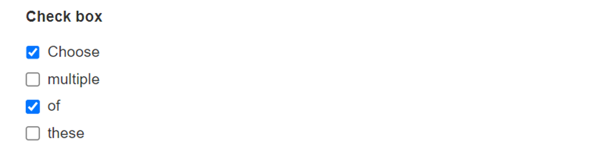

  check box

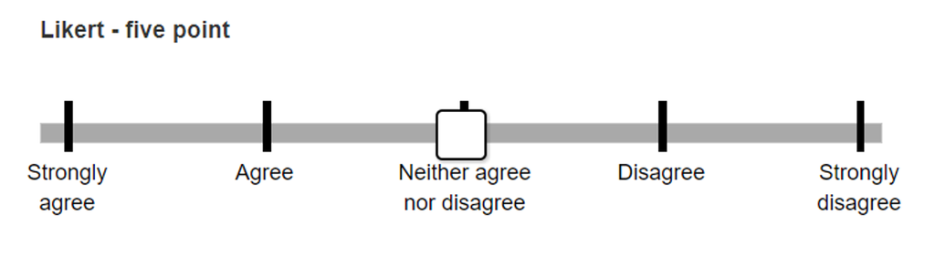

  Likert five

  5. `likert_seven`: participants can move a seven-point slider of the Likert scale (includes “Somewhat agree” and “Somewhat disagree”).Find out more information on the Likert scale [here](https://dictionary.apa.org/likert-scales).

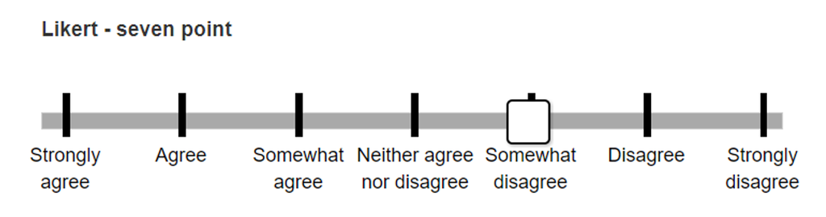

  Likert seven

- `start_response_options` - list of vectors containing `selectbox` or `checkbox` options for `start_questions.` The length of this list should be equal to the number of `selectbox` or `checkbox` responses used in `start_questions` and be in the order that these appear.

```r
start_questions = c(
  "How would you describe your gender?", # Q1
  "What country do you currently live in?", # Q2
  "Do you live in an area that you consider mainly…" # Q3
)

start_questions_ID = c("Gender", "Country", "Urbanicity")

start_questions_type = c("selectbox", "selectbox", "selectbox")

start_response_options = list(c('Male',  'Female',  'In another way', 'Prefer not to say'), # Q1 options
                               c('Scotland',  'England',  'Wales'), # Q2 options
                               c("Urban", "Rural")) # Q3 options
```

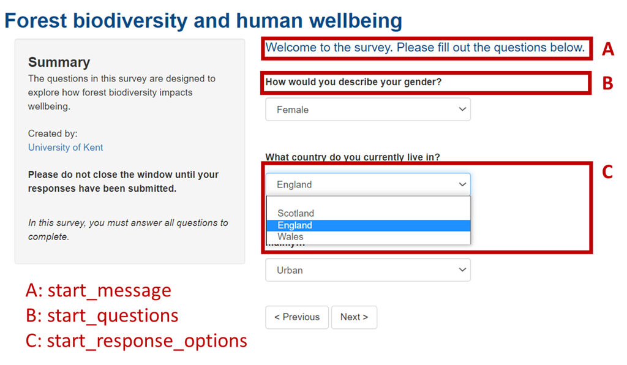

Example of start section

# Section 4: BIO-WELL

- `biowell_situations`: Text for describing an introductory scenario to cognitively situate the participant within a particular natural environment (i.e. a nearby forest).
- `biowell_questions`: A list the length of `biowell_situations`, in which each element contains a vector of the questions to be asked for each situation.

These stem questions are asked about biodiversity metrics (e.g. abundance, species diversity), as well as biodiversity attributes (e.g. smells, colours, shapes) within each `biowell_situation` given.

Table 2 demonstrates stem questions for a forest habitat. These can be adapted to other environments and contexts through either direct modification (e.g. change “woody smells” to “grassy smells” for urban parks) or through additional empirical work (e.g. focus groups) to identify relevant attributes.

- `biowell_situations_ID` - A string or vector (equal length to `biowell_situations`) providing a unique ID for each situation.
- `biowell_questions_ID`- A list the length of `biowell_situations` containing a string or vector the same length as the equivalent list element in `biowell_questions`, providing a unique ID for each BIO-WELL question. This is used in the resulting data frame of participant responses to avoid lengthy column names which occurs if question text is used.

**Table 2: BIO-WELL stem questions and IDs**

| Type | Description | biowell_questions | biowell_questions_ID |
| --- | --- | --- | --- |
| metric | encountering | Encountering the living things (e.g. plants, fungi and animals) in this forest makes me feel… | Encountering living things |
| metric | abundance | The number of living things (e.g. plants, fungi and animals) in this forest makes me feel… | Number of living things |
| metric | species diversity | The variety of living things (e.g. plants, fungi and animals) in this forest makes me feel… | Variety of living things |
| metric | species interactions | The interactions between plants, fungi and animals (e.g. pollination, predator-prey) in this forest make me feel… | Interactions between living things |
| metric | ecological processes | The living processes (e.g. decomposing, growing) that happen in this forest make me feel… | Living processes |
| attribute | sound | The variety of sounds in this forest makes me feel… | Variety of sounds |
| attribute | sound | The distinctive sounds in this forest make me feel… | Distinctive sounds |
| attribute | colour | The variety of colours in this forest makes me feel… | Variety of colours |
| attribute | colour | The vivid colours in this forest make me feel… | Vivid colours |
| attribute | shape | The variety of shapes in this forest make me feel… | Variety of shapes |
| attribute | shape | The maturity of living things (e.g. plants, fungi and animals) in this forest makes me feel… | Maturity of living things |
| attribute | texture | The variety of textures in this forest makes me feel… | Variety of textures |
| attribute | texture | The sponginess of living things (e.g. plants, fungi and animals) in this forest makes me feel… | Sponginess of living things |
| attribute | smell | The variety of smells in this forest makes me feel… | Variety of smells |
| attribute | smell | The woody smells in this forest make me feel… | Woody smells |
| attribute | behaviour | Changes in this season make me feel… | Changes in this season |
| attribute | behaviour | The presence of animals in this forest makes me feel… | Presence of animals |

To enter these as argument you would use the following code:

```r
biowell_situations = c(
  "For each of the following questions,  imagine yourself in a nearby forest at this time of year. Please think about the living things,  including the plants,  fungi and animals (but not pets,  horses,  cows,  sheep),  in that forest."
)

biowell_situations_ID = c("forest")

biowell_questions = list(
  c("encountering the living things (e.g. plants,  fungi and animals) in this forest makes me feel…",
    "The number of living things (e.g. plants,  fungi and animals) in this forest makes me feel…",
    "The variety of living things (e.g. plants,  fungi and animals) in this forest makes me feel…",
    "The interactions between plants,  fungi and animals (e.g. pollination, predator-prey) in this forest make me feel…",
    "The living processes (e.g. decomposing,  growing) that happen in this forest make me feel…",
    "The variety of sounds in this forest makes me feel…",
    "The distinctive sounds in this forest make me feel…",
    "The variety of colours in this forest makes me feel…",
    "The vivid colours in this forest make me feel…",
    "The variety of shapes in this forest make me feel…",
    "The maturity of living things (e.g. plants,  fungi and animals) in this forest makes me feel…",
    "The variety of textures in this forest makes me feel…",
    "The sponginess of living things (e.g. plants,  fungi and animals) in this forest makes me feel…",
    "The variety of smells in this forest makes me feel…",
    "The woody smells in this forest make me feel…",
    "Changes in this season make me feel...",
    "The presence of animals in this forest makes me feel…"))

  biowell_questions_ID = list(c("Encountering living things",
                                "Number of living things",
                                "Variety of living things",
                                "Interactions between living things",
                                "Living processes",
                                "Variety of sounds",
                                "Distinctive sounds",
                                "Variety of colours",
                                "Vivid colours",
                                "Variety of shapes",
                                "Maturity of living things",
                                "Variety of textures",
                                "Sponginess of living things",
                                "Variety of smells",
                                "Woody smells",
                                "Changes in this season",
                               "Presence of animals"))
```

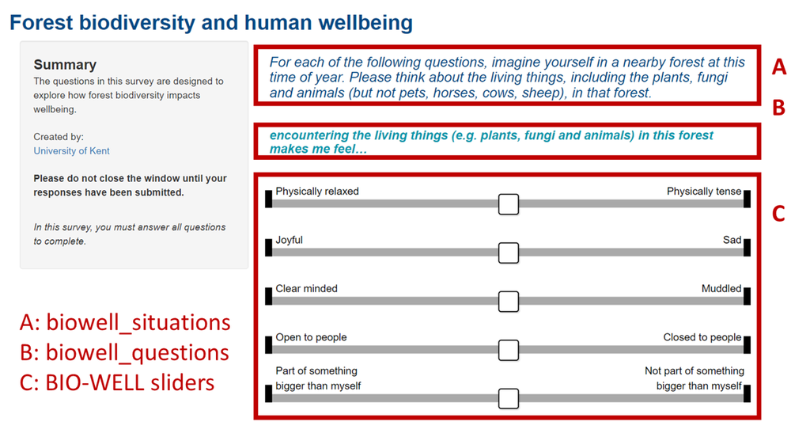

Example of BIO-WELL section

# Section 5: End

This is essentially a repeat of the Start section, but allows you to ask any additional questions you might want to include following the BIO-WELL questions. The provided questions allow you to explore participants’ use of the environmental space (woodlands) and any sensory impairments that might affect their experience of woodland biodiversity.

- `end_message` - Text introducing the end questions to participants.
- `end_questions`- A character string (1 question) or vector (2+ questions), the questions to ask participants after the BIO-WELL questions.
- `end_questions_ID` - A character string or vector (equal length to `end_questions`) providing a unique ID for each end question(s). This is used in the resulting data frame of participant responses to avoid lengthy column names which occurs if question text is used.
- `end_questions_type`- A character string or vector (equal length to `end_questions`) specifying the type of response box to provide for each `end_questions` (provide these in the same order as `end_questions`). We include five options:
  1. `text`: participants can freely type their responses.
  2. `selectbox`: participants can select one option from a drop down list.
  3. `checkbox`: participants can select one or more from list using check boxes.
  4. `likert_five`: participants can move a five-point slider to indicate their response on the Likert scale (“Strongly agree” to “Strongly disagree”). Find out more information on the Likert scale [here](https://dictionary.apa.org/likert-scales).
  5. `likert_seven`: participants can move a seven-point slider to indicate their response on the Likert scale (“Somewhat agree” and “Somewhat disagree”). Find out more information on the Likert scale [here](https://dictionary.apa.org/likert-scales).
- `end_response_options` - A list of vectors containing `selectbox` or `checkbox` options for `end_questions.` The length of this list should be equal to the number of `selectbox` or `checkbox` responses used in `end_questions` and be in the order that these appear.

```r
 end_message = "Please indicate how much you agree or disagree with each of the following statements. By ‘out of doors’ we mean open spaces in and around towns and cities, including parks, canals and nature areas; the coast and beaches; and the countryside including farmland, woodland, hills and rivers. It may include time spent close to your home or workplace, further afield or while on holiday in Wales, Scotland and England."

end_questions = c(
  "Please indicate how much you agree or disagree with each of the following statements. <br> As a child (up to 12 years old) I spent a lot of time in woodlands or forests",
  "As a teenager (13-18 years old) I spent a lot of time in woodlands or forests",
  "As an adult (18+ years old) I spent a lot of time in woodlands or forests",
  "Please select any difficulties you are experiencing at the moment with the following:"
)
end_questions_type = c("likert_five", "likert_five", "likert_five", "checkbox")

end_questions_ID = c("visits_aschild",
                     "visits_asteen",
                     "visits_asadult",
                     "impairment")

end_response_options = list(c("Being able to smell (for example, no sense of smell, having a cold or hay fever)", "Hearing (answer assuming you are wearing hearing aides if you need them)", "Sight (answer assuming you are wearing glasses or contact lenses if you need them)"))
```

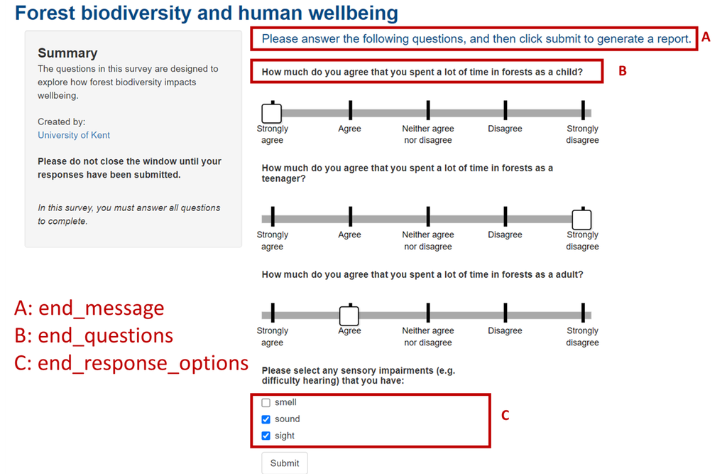

Example of end section

# Section 6: Report

- `user_report` - A logical (`TRUE` or `FALSE`) indicating whether participants should receive a summary of their BIO-WELL scores in the survey. The report also compares the current participant’s scores to those of previous participants.

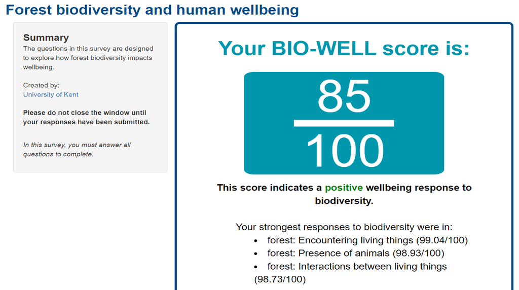

Example of user report

# Survey control options

When `offline_mode = TRUE`: survey responses are only stored locally to your temporary directory and not uploaded to Dropbox. This is useful when developing the survey before Dropbox has been set-up.

When `offline_mode = FALSE`: survey responses are remotely stored on Dropbox.

**Available languages**: ‘arabic’, ‘bengali_india’, ‘chinese_hong kong’, ‘chinese_taiwan’, ‘danish’, ‘dutch’, ‘edo’, ‘english’, ‘finnish’, ‘french’, ‘german’, ‘gujarati’, ‘indonesian’, ‘irish’, ‘italian’, ‘japanese’, ‘korean’, ‘malay’, ‘norwegian’, ‘polish’, ‘portuguese’, ‘portuguese_brasil’, ‘punjabi_india’, ‘punjabi_pakistan’, ‘russian’, ‘scottish_gaelic’, ‘spanish’, ‘swedish’, ‘urdu_india’, ‘urdu_pakistan’,‘welsh’

# Extra variables recorded

In addition to the participants responses to survey questions, the survey records the following variables with each submitted response:

- `survey_duration` - the time in seconds between the participants starting the survey and submitting their responses.
- `start_date` - the date that participants began the survey in YYYY-MM-DD format.
- `start_time` - the time that participants began the survey in HH-MM-SS format.
- `end_date` - the date that participants submitted their responses to the survey in YYYY-MM-DD format.
- `end_time` - the time that participants submitted their responses to the the survey in HH-MM-SS format.
- `timezone` - the time zone of participants.
- `timezone_location` - the broad location of the participant’s time zone.
- `server_submit_time` - the time in the Shiny Server’s time zone that participant responses were submitted.

# Finalising your survey

Whilst you are developing your custom BIO-WELL survey using `build_survey()`, ensure that you are working within the BIO-WELL survey folder that you created at the start of the Vignette.

Once you are happy with the design of your BIO-WELL survey, save the R script containing your `BIOWELL::build_survey()` input as “app.R” inside the folder created for your BIO-WELL survey. Ensure that no other lines of code are included in this script, and that the `build_survey()` function is called using the double colon operator.

- `BW_app_path` - Path to the folder for your BIO-WELL survey. This should contain your Dropbox token within a .secrets folder already (see Vignette 1 - `activate_dropbox()`).
- `Dropbox_App_folder` - Name of the folder within your Dropbox App (see Vignette 1) for response data to be stored within.

The folder for your BIO-WELL survey and Dropbox folder for storing survey data can have the same name for consistency, but can be different if you prefer.

## Example survey code to run

The code below contains the full input for running our example Shiny App BIO-WELL survey. An R script containing the below code should be saved manually in the directory for the app named “app.R”.

```r
BIOWELL::build_survey(
  survey_title = "Forest biodiversity and human wellbeing",
  sidepanel_message = "The questions in this survey are designed to explore the role forest biodiversity plays in wellbeing.",
  Dropbox_App_folder = "survey_responses",
  BW_app_path = paste0(tempdir(), "/my_app_name_1"),
  organisation = "BIOWELL package example",
  organisation_website = "https://github.com/r-a-dobson/BIOWELL",
  screen_message = "Consent to participate in research",
  screen_questions = c(
  "Participation is voluntary and you can withdraw from the study at any point by exiting
the survey before you submit, without providing any reason for why you no longer want your
responses to be included, and there will be no adverse consequences if you choose to
withdraw. As this survey is anonymised, it will not be possible to withdraw your responses
from the study after you click on 'Submit' at the end of the survey", # Question 1
  "What is your age?"),
  screen_questions_ID = c("Consent", "Age"),
  screen_response_options = list(
    c("No:SCREEN", "Yes"),
    c('0-17:SCREEN',  '18-29',  '30-59', 'Over 60',  'Prefer not to say')
  ),
  start_message = "Welcome to the survey. Please fill out the questions below.",
  start_questions = c(
    "How would you describe your gender?",
    "What country do you currently live in?",
    "Do you live in an area that you consider mainly…"
  ),
  start_questions_ID = c("Gender", "Country", "Urbanicity"),
  start_questions_type = c("selectbox", "selectbox", "selectbox"),
  start_response_options = list(
    c('Male',  'Female',  'In another way', 'Prefer not to say'),
    c('Scotland',  'England',  'Wales'),
    c("Urban", "Rural")
  ),
  biowell_situations = c(
    "For each of the following questions,  imagine yourself in a nearby forest at this time of year. Please think about the living things,  including the plants,  fungi and animals (but not pets,  horses,  cows,  sheep),  in that forest."
  ),
  biowell_situations_ID = c("forest"),
  biowell_questions = list(
    c(
      "Encountering the living things (e.g. plants,  fungi and animals) in this forest makes me feel…",
      "The number of living things (e.g. plants,  fungi and animals) in this forest makes me feel…",
      "The variety of living things (e.g. plants,  fungi and animals) in this forest makes me feel…",
      "The interactions between plants,  fungi and animals (e.g. pollination,  predator-prey) in this forest make me feel…",
      "The living processes (e.g. decomposing,  growing) that happen in this forest make me feel…",
      "The variety of sounds in this forest makes me feel…",
      "The distinctive sounds in this forest make me feel…",
      "The variety of colours in this forest makes me feel…",
      "The vivid colours in this forest make me feel…",
      "The variety of shapes in this forest make me feel…",
      "The maturity of living things (e.g. plants,  fungi and animals) in this forest makes me feel…",
      "The variety of textures in this forest makes me feel…",
      "The sponginess of living things (e.g. plants,  fungi and animals) in this forest makes me feel…",
      "The variety of smells in this forest makes me feel…",
      "The woody smells in this forest make me feel…",
      "Changes in this season make me feel...",
      "The presence of animals in this forest makes me feel…"
    )
  ),
  biowell_questions_ID = list(
    c(
      "Encountering living things",
      "Number of living things",
      "Variety of living things",
      "Interactions between living things",
      "Living processes",
      "Variety of sounds",
      "Distinctive sounds",
      "Variety of colours",
      "Vivid colours",
      "Variety of shapes",
      "Maturity of living things",
      "Variety of textures",
      "Sponginess of living things",
      "Variety of smells",
      "Woody smells",
      "Changes in this season",
      "Presence of animals"
    )
  ),
 end_questions = c(
  "As a child (up to 12 years old) I spent a lot of time in woodlands or forests",
  "As a teenager (13-18 years old) I spent a lot of time in woodlands or forests",
  "As an adult (18+ years old) I spent a lot of time in woodlands or forests",
  "Please select any difficulties you are experiencing at the moment with the following:"
),
  end_questions_type = c("likert_five", "likert_five", "likert_five", "checkbox"),
  end_questions_ID = c(
    "visits_aschild",
    "visits_asteen",
    "visits_asadult",
    "impairment"
  ),
 end_response_options = list(c("Being able to smell (for example, no sense of smell, having a cold or hay fever)", "Hearing (answer assuming you are wearing hearing aides if you need them)", "Sight (answer assuming you are wearing glasses or contact lenses if you need them)")),
  end_message = "Please indicate how much you agree or disagree with each of the following statements. By ‘out of doors’ we mean open spaces in and around towns and cities, including parks, canals and nature areas; the coast and beaches; and the countryside including farmland, woodland, hills and rivers. It may include time spent close to your home or workplace, further afield or while on holiday in Wales, Scotland and England.",
  all_questions = TRUE,
  all_sliders = TRUE,
  user_report = TRUE,
  offline = TRUE
)
```

```
#> Ensure your current working directory is your BIO-WELL app folder
```

[interactive chart not shown]